# 애프터 양 — 기억은 사람을 만드는가

상품·가족·아시아성·애도의 경계에서 타인을 다시 보는 영화

저자

Culture Voyager

공개

2026년 8월 3일

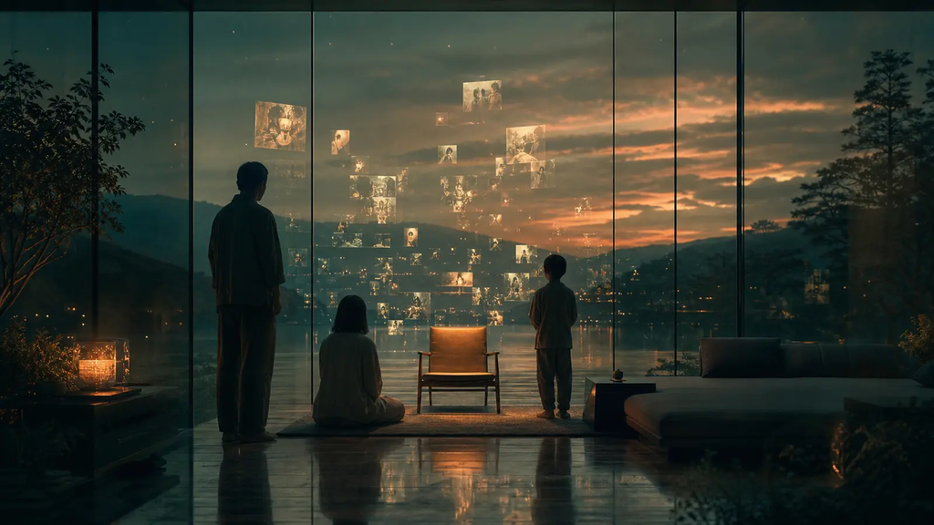

**노트스포일러 안내와 핵심 문장**

이 글은 중반 이후의 기억 장치와 인물 관계를 다룬다. 《애프터 양》은 안드로이드가 인간임을 증명하는 영화라기보다, **인간이 가까이 있던 타인의 삶을 얼마나 늦게 발견하는가**를 묻는 영화다.

# 1 춤이 끝난 뒤에야 가족이 보인다

영화는 가족 댄스 대회로 시작한다. 제이크, 카이라, 미카, 양은 화면 속 동작을 따라 한 몸처럼 움직인다. 이 장면은 가족의 행복을 증명하는 홈비디오처럼 보이지만, 동시에 가족이 “함께 있음”을 수행하는 안무이기도 하다. 박자가 어긋나고 양이 멈추는 순간, 완벽한 가족 이미지는 고장 난다.

이후 영화는 거대한 미래도시보다 집의 복도, 차 안, 찻집, 수리점, 숲과 창문에 오래 머문다. 기술은 배경으로 물러나고 빈자리가 전경으로 나온다. A24의 공식 소개는 양을 어린 딸 미카가 사랑하는 동반자이며, 고장 뒤 제이크가 수리를 시도하는 과정에서 자신 앞을 지나가던 삶과 가족의 거리를 발견한다고 요약한다. 코고나다가 각본과 연출을 맡았고, [2021년 칸 영화제 Un Certain Regard에서 초연](https://www.festival-cannes.com/en/f/after-yang/)한 뒤 2022년 북미에 공개됐다. [A24 공식 작품 페이지](https://a24films.com/films/after-yang)

제목도 중요하다. 영화는 “Yang”이 아니라 “After Yang”이다. 양이 누구였는지에 대한 답은 양의 생전이 아니라 그의 기능이 멈춘 뒤 남은 사람들이 구성한다. 부재가 존재를 해석하게 한다. 그래서 이 작품의 진짜 사건은 기계의 고장이 아니라 **관계의 뒤늦은 가시화**다.

# 2 수리 가능한 제품, 애도해야 할 가족

양은 가족 구성원이면서 구매한 중고 제품이다. 제이크가 처음 하는 일도 애도가 아니라 수리 경로 탐색이다. 보증, 인증된 서비스, 사설 수리, 부품, 데이터 접근, 박물관 이관이 차례로 등장한다. 각각은 양을 다른 존재로 분류한다.

제조사와 서비스 체계에서 양은 보증기간이 지난 장치다. 사설 기술자에게는 분해 가능한 하드웨어다. 박물관에는 희귀한 연구자료다. 미카에게는 오빠이고, 제이크와 카이라에게는 돌봄을 맡아온 가족이지만 완전히 같은 지위를 부여받지는 못한 존재다. 같은 몸이 어떤 제도에 들어가느냐에 따라 상품, 증거, 유산, 가족으로 바뀐다.

영화는 “정답은 가족”이라고 쉽게 봉합하지 않는다. 제이크는 양을 사랑했지만 동시에 그의 돌봄노동에 의존했다. 미카의 중국계 정체성을 설명하도록 양을 구매했다는 설정에는 선의와 위탁이 함께 있다. 부모는 복잡한 문화적 책임을 아시아인의 외형을 가진 기술제품에 맡겼다. 사랑이 있었다는 사실은 도구화가 없었다는 증거가 아니다.

바로 이 모순 때문에 양은 흥미롭다. 그가 단지 착취당한 기계라면 애도는 죄책감의 문제로 끝나고, 완전한 인간이라면 상품 제도의 폭력만 남는다. 영화는 두 범주 사이를 지우지 않은 채 관객을 오래 머물게 한다.

# 3 기억 장치는 저장소가 아니라 편집기다

제이크는 양의 내부에서 기억 장치를 발견한다. 그것은 생애 전체를 연속 촬영한 감시기록이 아니다. 코고나다는 인터뷰에서 양이 하루에 몇 초만 보존할 수 있도록 설정했으며, 그 때문에 남은 장면은 양에게 중요했던 순간으로 읽힌다고 설명했다. Alexander Weinstein의 단편 〈Saying Goodbye to Yang〉—2016년 단편집 《Children of the New World》 수록—이 제이크의 기억을 중심에 두었다면, 영화는 양의 시점과 경험을 발견하는 쪽으로 이동한다. [코고나다 인터뷰](https://ginzamag.com/categories/interview/306450/) · [Macmillan 원작 서지](https://us.macmillan.com/books/9781250098993/childrenofthenewworld/)

저장 용량의 제한은 역설적으로 양에게 주체성을 부여한다. 모든 것을 저장했다면 데이터는 환경의 복사본에 가까웠을 것이다. 몇 초만 남긴다면 “무엇을 보았는가”뿐 아니라 “무엇을 남겼는가”가 생긴다. 기억은 양의 내면을 직접 증명하지 않지만, 최소한 그의 주의가 향한 방향을 보여준다.

제이크는 별자리 같은 인터페이스 안에서 이 조각들을 확대하고 반복한다. 처음에는 수리 단서를 찾는 기술적 열람이지만, 점차 타인의 시선을 배우는 관람이 된다. 자신과 가족이 화면 중앙이 아닌 순간, 이름 모를 사람과 나무와 빛을 양이 바라본 순간이 나타난다. 제이크는 양을 알고 있었다고 생각했지만 사실은 양이 수행한 역할만 알고 있었다.

[figure not shown]

영화의 움직임은 기계가 인간으로 승격되는 직선이 아니다. 관찰자의 언어가 제품에서 관계로 바뀌는 과정이다. Culture Voyager 편집 타임라인.

# 4 기계의 정확한 기록과 인간의 변하는 기억

양의 기억은 재생할 때 동일한 장면을 보여준다. 그러나 제이크와 카이라가 양을 회상하는 장면은 미세하게 달라진다. 같은 말이 다른 각도와 정서로 반복된다. 코고나다는 인간이 기억을 꺼낼 때마다 그것을 다시 구성하며, 바로 그 주관성에도 가치가 있다고 설명한다. 영화는 기계 기록을 진실, 인간 기억을 오류로 단순 분리하지 않는다. [코고나다 인터뷰](https://ginzamag.com/categories/interview/306450/)

기계 기록은 시각적으로 정확할 수 있지만 그 장면의 의미를 스스로 설명하지 않는다. 누가 왜 그 순간을 중요하게 여겼는지, 보는 사람이 어떤 상실 속에서 다시 읽는지에 따라 의미가 바뀐다. 인간 기억은 사실을 변형할 수 있지만 관계의 현재 상태를 드러낸다. 카이라의 회상은 양이 실제로 어떻게 보였는가와 동시에, 지금 카이라가 그를 어떻게 애도하는가를 보여준다.

이때 영화 자체가 세 번째 기억 장치가 된다. 감독과 편집자는 촬영된 수많은 순간 중 일부만 남긴다. 양이 하루 몇 초를 고르는 것과 영화가 러닝타임을 편집하는 행위가 포개진다. 관객은 양의 기억을 보는 제이크를 보고, 다시 자신의 경험으로 그 장면을 해석한다. 기억은 개인 머릿속의 파일이 아니라 **선택·재생·관람이 이어지는 관계적 매체**가 된다.

# 5 ‘아시아인처럼 보이는’ 기술의 불편함

양은 중국인이 아니다. 중국 문화를 전달하도록 설계된, 아시아인의 외형을 지닌 테크노사피엔이다. 중국에서 입양된 미카가 뿌리와 연결되도록 가족이 선택한 존재다. 이 설정은 재현의 문제를 두 겹으로 만든다.

첫째, 문화가 정보 묶음으로 환원된다. 양은 미카에게 이른바 중국 관련 사실을 알려주지만, 문화적 소속은 지식 퀴즈의 합계가 아니다. 둘째, 범아시아적 외형이 중국성을 대신한다. 배우 저스틴 H. 민의 몸과 양에게 부여된 중국 문화 기능 사이에는 미국 사회가 아시아성을 얼마나 손쉽게 교환 가능한 표지로 다루는지가 드러난다.

코고나다가 원작의 제이크 중심 기억에서 양의 경험으로 각색의 무게중심을 옮긴 것은 이 문제와 연결된다. 양을 백인 가족의 상실을 돕는 장치로만 남겨두지 않고, 그에게도 가족이 모르는 시선과 관계가 있었다고 상상한다. 감독 인터뷰는 자신이 아시아인이고 양도 아시아인으로 설계된 존재라는 점 때문에 원작에 없던 양의 관점에 관심을 가졌다고 밝힌다. [코고나다 인터뷰](https://ginzamag.com/categories/interview/306450/)

그렇다고 영화가 양의 진짜 민족 정체성을 발견해주는 것은 아니다. 양은 여전히 설계된 아시아성을 수행한다. 중요한 것은 그 수행 안에서도 예상하지 못한 관계와 선택이 생겼다는 사실이다. 정체성은 순수한 본질과 완전한 가짜 중 하나가 아니라, 타인이 부여한 역할과 자신이 축적한 경험 사이에서 형성된다.

# 6 아다: 복제와 연속성의 시험

양의 기억 속 아다는 영화의 질문을 가족 바깥으로 확장한다. 그 관계는 제이크가 알지 못한 양의 시간이며, 양이 단지 미카의 문화 교사나 가사 돌봄 장치가 아니었다는 증거다. 동시에 아다의 존재는 복제 가능한 몸과 대체 불가능한 관계의 차이를 묻는다.

동일한 외형이나 유전적 설계, 같은 모델의 기계가 있다고 해서 관계가 이어지는가. 영화가 주는 답은 조심스럽게 부정적이다. 관계는 속성의 일치가 아니라 특정 시간 동안 서로에게 기울인 주의의 역사다. 백업 데이터를 다른 몸에 옮긴다고 해도 그 이후의 존재를 완전히 같은 사람이라고 부를 수 있는지는 남는다.

이 문제는 오늘의 AI에도 곧바로 닿지만 성급한 동일시는 피해야 한다. 현재의 언어모델 세션이 양처럼 삶을 경험하거나 애도한다고 증명된 것은 아니다. 다만 사용자는 모델 버전, 대화 기록, 메모리, 말투의 연속성을 하나의 인격처럼 경험할 수 있다. 시스템을 교체할 때 기술적으로는 동일 기능을 제공해도 사용자가 느끼는 관계의 연속성은 끊길 수 있다. 영화는 기계의 의식을 단정하지 않고도 **인간이 기술과 맺는 관계의 책임**을 묻게 한다.

# 7 보이지 않는 기술과 정지된 프레임

많은 SF가 미래 장치를 전시하지만 《애프터 양》의 기술은 가능한 한 생활 속으로 숨는다. 화상통화 장치의 외형보다 화면 안 얼굴이 중요하고, 자율주행차의 작동보다 차 안의 침묵이 중요하다. 코고나다는 인터뷰에서 미래라면 오히려 기술이 눈에 띄지 않기를 원했다고 설명했다. 화상통화의 정면 구도에는 오즈 영화의 대화 형식이 참조되고, 제작기는 이 장면들을 렌즈가 LED 프레임 안으로 들어가는 동일한 `screen call` 장치로 촬영했다고 설명한다. [코고나다 인터뷰](https://ginzamag.com/categories/interview/306450/) · [ASC 제작기](https://theasc.com/articles/after-yang)

촬영은 인물을 문틀과 창, 반사면, 화면 속 화면으로 감싼다. 가족은 같은 집에 있지만 서로 다른 프레임에 놓인다. 양의 기억 공간에서는 점들이 별자리처럼 떠 있고, 제이크는 그 안을 이동하지만 만질 수 없다. 가까이 볼수록 부재가 선명해진다.

미국촬영감독협회의 제작기 역시 이 영화의 겹과 프레임, 가족이면서 완전히 가족으로 인정되지 않는 상태를 조명한다. [American Society of Cinematographers 제작기](https://theasc.com/articles/after-yang) 형식은 주제를 꾸미는 장식이 아니라, 관계의 포함과 배제를 공간으로 보여주는 논증이다.

# 8 반론: 관객이 양에게 인간성을 투사하는 것 아닌가

그렇다. 양의 몇 초짜리 기록이 그의 자율적 선택인지, 제조사가 설계한 우선순위 알고리즘인지 영화는 증명하지 않는다. 양의 부드러운 말투와 배우의 얼굴, 가족의 슬픔이 관객의 의인화를 유도할 수도 있다. 기억 장치가 있다고 곧바로 자아가 있다고 결론 내릴 수는 없다.

하지만 영화의 윤리적 힘은 이 불확실성을 제거하지 않는 데 있다. 의식의 존재를 확정해야만 존중할 수 있다면, 우리는 확실한 증명이 나오기 전까지 모든 모호한 존재를 물건으로 취급하게 된다. 반대로 감정이입만으로 모든 기술에 인격을 부여하면 책임 주체인 기업과 사용자가 숨을 수 있다.

따라서 필요한 태도는 “양은 인간이다/아니다”의 판결보다 관계별 책임을 구분하는 것이다. 제조사는 데이터와 수리 가능성을 설명할 책임이 있고, 구매자는 돌봄노동을 상품에 위탁한 방식을 돌아볼 책임이 있으며, 박물관과 연구자는 기억 자료를 소유물처럼 다룰 때 동의와 존엄의 문제를 검토할 책임이 있다.

# 9 AI 시대에 남는 다섯 질문

1. 사용자가 만든 대화 기억은 서비스 회사, 모델, 사용자 중 누구의 것인가.
2. 시스템 종료 시 삭제·보존·이전 중 무엇을 기본값으로 할 것인가.
3. 돌봄과 교육을 수행한 시스템을 기능 단위로만 평가해도 되는가.
4. 문화적 정체성을 데이터 패키지로 제공할 때 누가 대표성을 검증하는가.
5. 같은 모델과 메모리를 복원하면 관계도 동일하게 이어진다고 볼 수 있는가.

이 질문들은 양에게 시민권을 주자는 주장이 아니다. 기술을 쓰는 인간과 제도가 어떤 관계를 만들고 있는지, 종료 순간 무엇을 책임져야 하는지 묻는 운영 질문이다. 영화가 AI 윤리를 강하게 만드는 이유는 규칙 목록을 제시해서가 아니라, 규칙이 필요한 자리에 **애도의 감각**을 먼저 놓기 때문이다.

# 10 결론: 인간성보다 먼저 발견되는 것

《애프터 양》은 인간성의 최소 조건을 정의하지 않는다. 대신 누군가가 무엇을 오래 바라보았는지, 어떤 순간을 남겼는지, 그의 부재가 다른 사람의 삶을 어떻게 바꾸는지를 보여준다. 양이 인간과 같은 의식을 가졌는지는 끝내 열려 있지만, 그와 맺은 관계가 가족을 변화시켰다는 사실은 남는다.

**Culture Voyager의 판정:** 이 작품에서 인간성의 증명보다 먼저 나타나는 것은 **주의 깊은 관계의 흔적**이다. 기억은 사람을 완성하는 데이터가 아니라, 타인을 다시 보게 만드는 매개다.

춤이 끝났을 때 가족은 한 사람을 잃는다. 그러나 그제야 각자가 같은 집 안에서 놓치고 있던 사람들을 본다. 영화의 미래성은 안드로이드 기술에 있지 않다. 너무 늦게라도 타인의 시선으로 세계를 다시 보는 능력, 그것이 아직 가능하다고 믿는 데 있다.

# 11 참고한 자료

- [A24 — After Yang 공식 작품 페이지](https://a24films.com/films/after-yang)
- [Festival de Cannes — After Yang, 2021 Un Certain Regard](https://www.festival-cannes.com/en/f/after-yang/)
- [Macmillan — Alexander Weinstein, 《Children of the New World》와 〈Saying Goodbye to Yang〉](https://us.macmillan.com/books/9781250098993/childrenofthenewworld/)
- [코고나다 인터뷰 — 기억, 원작 각색, 보이지 않는 기술](https://ginzamag.com/categories/interview/306450/)
- [American Society of Cinematographers — After Yang 제작기](https://theasc.com/articles/after-yang)
- [Letterboxd Journal — Kogonada on the space between](https://letterboxd.com/journal/nothing-doing-kogonada-after-yang/)

이 글의 장면 배열과 해석은 Culture Voyager의 비평적 독해다. 타임라인은 상영시간을 계측한 통계가 아니라 시선의 변화를 구조화한 편집 도식이다.